# chromosomix on a laptop

Time and memory of genome-wide analyses, run once each on the machine that renders this page

**Rendered** 30 October 2026, 11:38 UTC · **chromosomix** 0.18.0, release v0.18.0, at [`b1f1a7a3`](https://github.com/js2264/chromosomix/commit/b1f1a7a32b15903eac99ca53b75d79aae4f3d03f)  
**By** hand, on the machine below, as this page is published  
**On** Apple M1 Pro, 10 cores, 16 GB, Darwin 23.6.0 (arm64); Python 3.12.13, Quarto 1.3.433

The same analyses against the packages they reproduce: [the timings](https://chromosomix.app/timings/). Every analysis measured, with the machine, is a table to download under the results.

How long does an analysis take in chromosomix, and how much memory does it need, when it is run over a whole genome on an ordinary laptop? This notebook answers that for 23 analyses on public data: Hi-C maps from 69 million to 1.08 billion contacts, a yeast Micro-C map down to 50 bp, and ATAC-seq tracks and sequence over the whole mouse genome.

Each analysis is run once through `chromosomix`, the command-line form of the app’s Analysis panel. It runs the same code the browser runs, and as a separate process its time and memory can be measured by the operating system: the wall-clock time from start to finish, the CPU time, and the peak memory (the largest resident set the process reached).

The block above says which machine this page was rendered on. The page published at https://chromosomix.app/laptop/ is rendered by hand, on a laptop, and committed as `notebooks/laptop.html`; `.github/workflows/notebooks.yml` renders it on a GitHub runner with every release too, but keeps that render as the run’s artifact and never publishes it. To measure your own, render it from the root of a clone, on a laptop that is plugged in and otherwise idle:

```bash
npm ci && npm run build:cli
pip install jupyter pandas matplotlib pyfaidx
quarto render notebooks/laptop.qmd
```

The page is one file and carries its table and its stamp inside it, so committing `notebooks/laptop.html` is all it takes to publish a render: the site’s build unpacks the two beside it.

```python
import hashlib
import os
import platform
import shutil
import subprocess
import sys
import tempfile
import time
import urllib.request
from pathlib import Path

import matplotlib.pyplot as plt
from matplotlib.patches import Patch
import pandas as pd
import pyfaidx

REDO = False

HERE = Path.cwd().resolve()
REPO = HERE.parent if HERE.name == 'notebooks' else HERE
CLI = REPO / 'dist-cli' / 'chromosomix.mjs'
WORK = REPO / 'notebooks' / 'work' / 'laptop'
DATA = WORK / 'data'
TIMINGS = WORK / 'timings.tsv'
DATA.mkdir(parents=True, exist_ok=True)

if not CLI.exists():
    raise FileNotFoundError(f'{CLI} is not there: run `npm run build:cli` first.')
VERSION = subprocess.run(['node', str(CLI), '--version'], capture_output=True, text=True).stdout.split('\n')[0]
```

## The machine

```python
MACHINE = {
    'processor': R.machine['processor'],
    'cores': os.cpu_count(),
    'memory': f"{R.machine['memory_gb']:.0f} GB",
    'system': platform.platform(),
    'node': subprocess.run(['node', '--version'], capture_output=True, text=True).stdout.strip(),
    'chromosomix': VERSION.removeprefix('chromosomix '),
}
pd.DataFrame(MACHINE.items(), columns=['', 'this machine']).style.hide(axis='index')
```

|  | this machine |
| --- | --- |
| processor | Apple M1 Pro |
| cores | 10 |
| memory | 16 GB |
| system | macOS-14.6.1-arm64-arm-64bit |
| node | v24.14.0 |
| chromosomix | 0.18.0 (b1f1a7a3) |

## The data

| Data | Source | Contacts | Size |
| --- | --- | --- | --- |
| Mouse Hi-C, mm10 | 4DN 4DNFIOZ1TRUS | 69 million | 0.7 GB |
| Human Hi-C, IMR-90, GRCh38 (Rao et al. 2014) | 4DN 4DNFIJTOIGOI | 1.08 billion | 8.3 GB |
| Yeast Micro-C (Costantino et al. 2020) | GEO GSE151553 | 51 million | 0.1 GB |
| Mouse ATAC-seq, two replicates | 4DN 4DNFIIY4QW2D, 4DNFITBRHVZE |  | 1.7 GB |
| Mouse genome sequence and RefSeq genes, mm10 | UCSC, as Illumina iGenomes distributes them |  | 2.9 GB |

Every file is checked against its MD5 when it is downloaded. The mouse sequence is indexed beside itself (`mm10.fa.fai`) so that it is read by range.

```python
FOURDN = 'https://4dn-open-data-public.s3.amazonaws.com/fourfront-webprod/wfoutput'
IGENOMES = 'https://ngi-igenomes.s3.amazonaws.com/igenomes/Mus_musculus/UCSC/mm10'
GEO = 'https://ftp.ncbi.nlm.nih.gov/geo/series'
FILES = {
    '4DNFIOZ1TRUS.mcool': (f'{FOURDN}/727b405d-c9f5-4b13-ae58-1dbf29d19a8f/4DNFIOZ1TRUS.mcool',
                           '503fea3d171e9c5c7f8a5403af73481e'),
    '4DNFIJTOIGOI.mcool': (f'{FOURDN}/b4939d95-4121-4f86-9cc8-29a34eb834ef/4DNFIJTOIGOI.mcool',
                           '659f9dc7613650494aa5ed4138e2e17e'),
    'GSE151553_A364_merged.mcool': (f'{GEO}/GSE151nnn/GSE151553/suppl/GSE151553_A364_merged.mcool',
                                    '319a04a8d7e41d9eb88e2378ea3ea373'),
    '4DNFIIY4QW2D.bw': (f'{FOURDN}/7fb6d419-a8de-4bc8-9c17-f68f814496a2/4DNFIIY4QW2D.bw',
                        '9f8a3a413f54129a689548a93584cdf4'),
    '4DNFITBRHVZE.bw': (f'{FOURDN}/e567a80e-c7d2-41ff-b12d-67047906c076/4DNFITBRHVZE.bw',
                        '99c928ea99ee1a2a7ec7091260f1e4be'),
    'mm10.fa': (f'{IGENOMES}/Sequence/WholeGenomeFasta/genome.fa', '34d90c586dc92f5c3e8df3ed24530f4f'),
    'mm10.genes.gtf': (f'{IGENOMES}/Annotation/Genes/genes.gtf', '543ec24bb11a4ff0cf5aa4f695320b82'),
}
VALIDATION_DATA = REPO / 'notebooks' / 'work' / 'validation' / 'data'


def md5(path):
    digest = hashlib.md5()
    with open(path, 'rb') as handle:
        for block in iter(lambda: handle.read(1 << 22), b''):
            digest.update(block)
    return digest.hexdigest()


def fetch(name, url, expected):
    path = DATA / name
    if path.exists():
        return
    if (VALIDATION_DATA / name).exists():
        path.symlink_to(VALIDATION_DATA / name)
        return
    print('downloading', url)
    part = path.with_name(name + '.part')
    with urllib.request.urlopen(url) as response, open(part, 'wb') as out:
        shutil.copyfileobj(response, out, 1 << 22)
    if md5(part) != expected:
        part.unlink()
        raise ValueError(f'{url} did not download as published: its MD5 is not {expected}.')
    part.rename(path)


for name, (url, expected) in FILES.items():
    fetch(name, url, expected)
pyfaidx.Faidx(str(DATA / 'mm10.fa')).close()

pd.DataFrame([{'file': name, 'GB': round((DATA / name).stat().st_size / 1e9, 2)} for name in FILES]) \
    .style.hide(axis='index').format(precision=2)
```

| file | GB |
| --- | --- |
| 4DNFIOZ1TRUS.mcool | 0.69 |
| 4DNFIJTOIGOI.mcool | 8.31 |
| GSE151553_A364_merged.mcool | 0.12 |
| 4DNFIIY4QW2D.bw | 0.96 |
| 4DNFITBRHVZE.bw | 0.74 |
| mm10.fa | 2.78 |
| mm10.genes.gtf | 0.09 |

## The analyses

Each analysis is one command, run from `notebooks/work/laptop/` with its output in `out/<name>/`. Two of them read another’s output: the pileup (APA) is over the loops chromosight called, and the overlap is of the peaks called on the ATAC-seq replicates against the RefSeq transcripts. Parameters are the app’s defaults, except where the validation notebook uses others for the same analysis.

```python
MOUSE, HUMAN, YEAST = 'data/4DNFIOZ1TRUS.mcool', 'data/4DNFIJTOIGOI.mcool', 'data/GSE151553_A364_merged.mcool'
ATAC1, ATAC2, MM10, GENES = 'data/4DNFIIY4QW2D.bw', 'data/4DNFITBRHVZE.bw', 'data/mm10.fa', 'data/mm10.genes.gtf'
LOOPS = 'out/chromosight/4DNFIOZ1TRUS_10000.chromosight.chromosight-patterns.bedpe'
PEAKS = 'out/peaks/4DNFIIY4QW2D.peaks.peaks-data_4DNFIIY4QW2D_bw-data_4DNFITBRHVZE_bw.bed'


def at(path, bp):
    return f'{path}::/resolutions/{bp}'


# name, data, analysis, resolution, and the command after `chromosomix`
TASKS = [
    ('coverage', 'Mouse Hi-C', 'Coverage, balanced', '10 kb',
     ['coverage', at(MOUSE, 10_000), '--balance']),
    ('expected', 'Mouse Hi-C', 'P(s)', '10 kb',
     ['expected', at(MOUSE, 10_000), '--quantity', 'expected', '--scope', 'file']),
    ('insulation', 'Mouse Hi-C', 'Insulation, 100 kb window, boundaries', '10 kb',
     ['insulation', at(MOUSE, 10_000), '--window', '10']),
    ('di', 'Mouse Hi-C', 'Directionality index, 2 Mb window, borders', '50 kb',
     ['di', at(MOUSE, 50_000), '--window', '40']),
    ('compartments', 'Mouse Hi-C', 'Compartments (E1) and saddle', '100 kb',
     ['compartments', at(MOUSE, 100_000)]),
    ('loops', 'Mouse Hi-C', 'Loop calling (cooltools dots), to 10 Mb', '10 kb',
     ['loops', at(MOUSE, 10_000)]),
    ('chromosight', 'Mouse Hi-C', 'Loop detection (chromosight), to 2 Mb', '10 kb',
     ['chromosight', at(MOUSE, 10_000), '--pattern', 'loops']),
    ('apa', 'Mouse Hi-C', "APA over chromosight's loops", '10 kb',
     ['apa', at(MOUSE, 10_000), '--pairs', LOOPS]),
    ('model', 'Mouse Hi-C', '3D model of the genome (pastis-NB)', '1 Mb',
     ['reconstruct3d', at(MOUSE, 1_000_000), '--method', 'nb', '--alpha', '3']),

    ('human-coverage', 'Human Hi-C', 'Coverage, balanced', '10 kb',
     ['coverage', at(HUMAN, 10_000), '--balance']),
    ('human-expected', 'Human Hi-C', 'P(s)', '10 kb',
     ['expected', at(HUMAN, 10_000), '--quantity', 'expected', '--scope', 'file']),
    ('human-insulation', 'Human Hi-C', 'Insulation, 100 kb window, boundaries', '10 kb',
     ['insulation', at(HUMAN, 10_000), '--window', '10']),
    ('human-compartments', 'Human Hi-C', 'Compartments (E1) and saddle', '100 kb',
     ['compartments', at(HUMAN, 100_000)]),
    ('human-loops', 'Human Hi-C', 'Loop calling (cooltools dots), to 10 Mb', '10 kb',
     ['loops', at(HUMAN, 10_000)]),

    ('yeast-expected', 'Yeast Micro-C', 'P(s)', '50 bp',
     ['expected', at(YEAST, 50), '--quantity', 'expected', '--scope', 'file']),
    ('yeast-chromosight', 'Yeast Micro-C', 'Loop detection (chromosight)', '800 bp',
     ['chromosight', at(YEAST, 800), '--pattern', 'loops']),
    ('yeast-model', 'Yeast Micro-C', '3D model of the genome (pastis-NB)', '12.8 kb',
     ['reconstruct3d', at(YEAST, 12_800), '--method', 'nb', '--alpha', '3']),

    ('peaks', 'Mouse ATAC-seq, mm10', 'Peak calling with IDR, two replicates', '1 bp',
     ['peaks', '--signal', ATAC1, '--replicate', ATAC2, '--width', '150', '--times', '3', '--minWidth', '75',
      '--truncate', '100000', '--idr', '0.05']),
    ('overlap', 'Mouse ATAC-seq, mm10', 'Overlap of the peaks with transcripts, 1,000 shuffles', '1 bp',
     ['overlap', '--sequence', MM10, '--features', PEAKS, '--features', GENES, '--a', PEAKS, '--b', GENES,
      '--shuffle', '--iterations', '1000', '--seed', '1']),
    ('metaplot', 'Mouse ATAC-seq, mm10', 'Metaplot at every RefSeq TSS, ±2 kb', '50 bp',
     ['metaplot', '--tracks', ATAC1, '--features', GENES, '--mode', 'reference', '--at', 'start', '--flank',
      '2000', '--step', '50', '--band', 'none']),
    ('trackcorr', 'Mouse ATAC-seq, mm10', 'Correlation of the two replicates (Spearman)', '1 kb',
     ['trackcorr', '--tracks', f'{ATAC1},{ATAC2}', '--binsize', '1000', '--method', 'spearman']),
    ('composition', 'Mouse ATAC-seq, mm10', 'Base composition: GC, skews', '10 kb',
     ['composition', '--sequence', MM10, '--resolution', '10000']),
    ('motif', 'Mouse ATAC-seq, mm10', 'Motif search, CTCF core, ≤ 1 mismatch', '1 bp',
     ['motif', '--sequence', MM10, '--pattern', 'CCGCGNGGNGGCAG', '--mismatches', '1']),
]
```

Each command runs as a process of its own, and `os.wait4` returns what the system counted of it: its CPU time, user and system, and its peak resident memory (`ru_maxrss`, which macOS gives in bytes and Linux in kilobytes).

```python
def run(name, args):
    """One command: its wall-clock and CPU seconds, and its peak memory in MB."""
    out = WORK / 'out' / name
    shutil.rmtree(out, ignore_errors=True)
    out.mkdir(parents=True)
    with tempfile.TemporaryFile() as err:
        start = time.perf_counter()
        process = subprocess.Popen(['node', str(CLI), *args, '--out', f'out/{name}', '--quiet'], cwd=WORK,
                                   stdout=subprocess.DEVNULL, stderr=err)
        _, status, usage = os.wait4(process.pid, 0)
        wall = time.perf_counter() - start
        if os.waitstatus_to_exitcode(status):
            err.seek(0)
            raise RuntimeError(f'chromosomix {" ".join(args)} failed:\n{err.read().decode()[-3000:]}')
    peak = usage.ru_maxrss / (2**20 if sys.platform == 'darwin' else 2**10)
    return {'wall_s': wall, 'cpu_s': usage.ru_utime + usage.ru_stime, 'peak_mb': peak}


# Results from an earlier render of this same build are kept; the others are run, and saved one by one.
done = pd.read_csv(TIMINGS, sep='\t') if TIMINGS.exists() and not REDO else pd.DataFrame()
if len(done):
    done = done[done['chromosomix'] == MACHINE['chromosomix']]
rows = done.to_dict('records')
for name, data, analysis, resolution, args in TASKS:
    if any(row['name'] == name for row in rows):
        continue
    cost = run(name, args)
    rows.append({'name': name, 'data': data, 'analysis': analysis, 'resolution': resolution, **cost,
                 'command': 'chromosomix ' + ' '.join(args), **MACHINE})
    pd.DataFrame(rows).to_csv(TIMINGS, sep='\t', index=False)
times = pd.DataFrame(rows).set_index('name').loc[[task[0] for task in TASKS]].reset_index()
```

## Results

Every analysis measured, with its command and the machine: `timings.tsv`.

```python
def duration(seconds):
    return f'{seconds:.1f} s' if seconds < 60 else f'{seconds / 60:.1f} min'


table = times.assign(time=times['wall_s'].map(duration), cpu=times['cpu_s'].map(duration),
                     memory=times['peak_mb'].round().astype(int))
table[['data', 'analysis', 'resolution', 'time', 'cpu', 'memory']] \
    .rename(columns={'time': 'wall-clock time', 'cpu': 'CPU time', 'memory': 'peak memory (MB)'}) \
    .style.hide(axis='index').format({'peak memory (MB)': '{:,}'})
```

| data | analysis | resolution | wall-clock time | CPU time | peak memory (MB) |
| --- | --- | --- | --- | --- | --- |
| Mouse Hi-C | Coverage, balanced | 10 kb | 4.4 s | 4.3 s | 355 |
| Mouse Hi-C | P(s) | 10 kb | 3.3 s | 3.7 s | 332 |
| Mouse Hi-C | Insulation, 100 kb window, boundaries | 10 kb | 5.0 s | 6.0 s | 353 |
| Mouse Hi-C | Directionality index, 2 Mb window, borders | 50 kb | 2.5 s | 3.0 s | 244 |
| Mouse Hi-C | Compartments (E1) and saddle | 100 kb | 4.0 s | 5.1 s | 460 |
| Mouse Hi-C | Loop calling (cooltools dots), to 10 Mb | 10 kb | 28.3 s | 30.9 s | 637 |
| Mouse Hi-C | Loop detection (chromosight), to 2 Mb | 10 kb | 26.9 s | 28.7 s | 445 |
| Mouse Hi-C | APA over chromosight's loops | 10 kb | 5.9 s | 7.2 s | 285 |
| Mouse Hi-C | 3D model of the genome (pastis-NB) | 1 Mb | 45.8 s | 46.5 s | 367 |
| Human Hi-C | Coverage, balanced | 10 kb | 18.8 s | 20.6 s | 421 |
| Human Hi-C | P(s) | 10 kb | 17.8 s | 19.5 s | 400 |
| Human Hi-C | Insulation, 100 kb window, boundaries | 10 kb | 20.9 s | 21.6 s | 375 |
| Human Hi-C | Compartments (E1) and saddle | 100 kb | 10.2 s | 11.6 s | 543 |
| Human Hi-C | Loop calling (cooltools dots), to 10 Mb | 10 kb | 58.3 s | 1.0 min | 1,020 |
| Yeast Micro-C | P(s) | 50 bp | 2.6 s | 2.6 s | 312 |
| Yeast Micro-C | Loop detection (chromosight) | 800 bp | 4.8 s | 5.6 s | 365 |
| Yeast Micro-C | 3D model of the genome (pastis-NB) | 12.8 kb | 6.1 s | 6.3 s | 238 |
| Mouse ATAC-seq, mm10 | Peak calling with IDR, two replicates | 1 bp | 1.8 min | 1.9 min | 545 |
| Mouse ATAC-seq, mm10 | Overlap of the peaks with transcripts, 1,000 shuffles | 1 bp | 7.8 s | 7.8 s | 547 |
| Mouse ATAC-seq, mm10 | Metaplot at every RefSeq TSS, ±2 kb | 50 bp | 5.3 s | 6.0 s | 755 |
| Mouse ATAC-seq, mm10 | Correlation of the two replicates (Spearman) | 1 kb | 18.2 s | 20.0 s | 648 |
| Mouse ATAC-seq, mm10 | Base composition: GC, skews | 10 kb | 4.9 s | 4.9 s | 394 |
| Mouse ATAC-seq, mm10 | Motif search, CTCF core, ≤ 1 mismatch | 1 bp | 42.7 s | 42.5 s | 209 |

```python
slowest = times.loc[times['wall_s'].idxmax()]
largest = times.loc[times['peak_mb'].idxmax()]
under_a_minute = int((times['wall_s'] < 60).sum())
```

The CPU time is close to the wall-clock time because chromosomix computes on one thread; it can be slightly higher, as Node collects garbage and compiles on threads of its own.

The mouse and human Hi-C maps differ 16-fold in depth (69 million and 1.08 billion contacts), on genomes of about the same size. The same five analyses on each:

```python
pairs = []
for name in ['coverage', 'expected', 'insulation', 'compartments', 'loops']:
    mouse = times.set_index('name').loc[name]
    human = times.set_index('name').loc[f'human-{name}']
    pairs.append({'analysis': mouse['analysis'], 'resolution': mouse['resolution'],
                  'time, 69 M': duration(mouse['wall_s']), 'time, 1.08 B': duration(human['wall_s']),
                  'memory, 69 M (MB)': round(mouse['peak_mb']), 'memory, 1.08 B (MB)': round(human['peak_mb'])})
pd.DataFrame(pairs).style.hide(axis='index').format('{:,}', subset=['memory, 69 M (MB)', 'memory, 1.08 B (MB)'])
```

| analysis | resolution | time, 69 M | time, 1.08 B | memory, 69 M (MB) | memory, 1.08 B (MB) |
| --- | --- | --- | --- | --- | --- |
| Coverage, balanced | 10 kb | 4.4 s | 18.8 s | 355 | 421 |
| P(s) | 10 kb | 3.3 s | 17.8 s | 332 | 400 |
| Insulation, 100 kb window, boundaries | 10 kb | 5.0 s | 20.9 s | 353 | 375 |
| Compartments (E1) and saddle | 100 kb | 4.0 s | 10.2 s | 460 | 543 |
| Loop calling (cooltools dots), to 10 Mb | 10 kb | 28.3 s | 58.3 s | 637 | 1,020 |

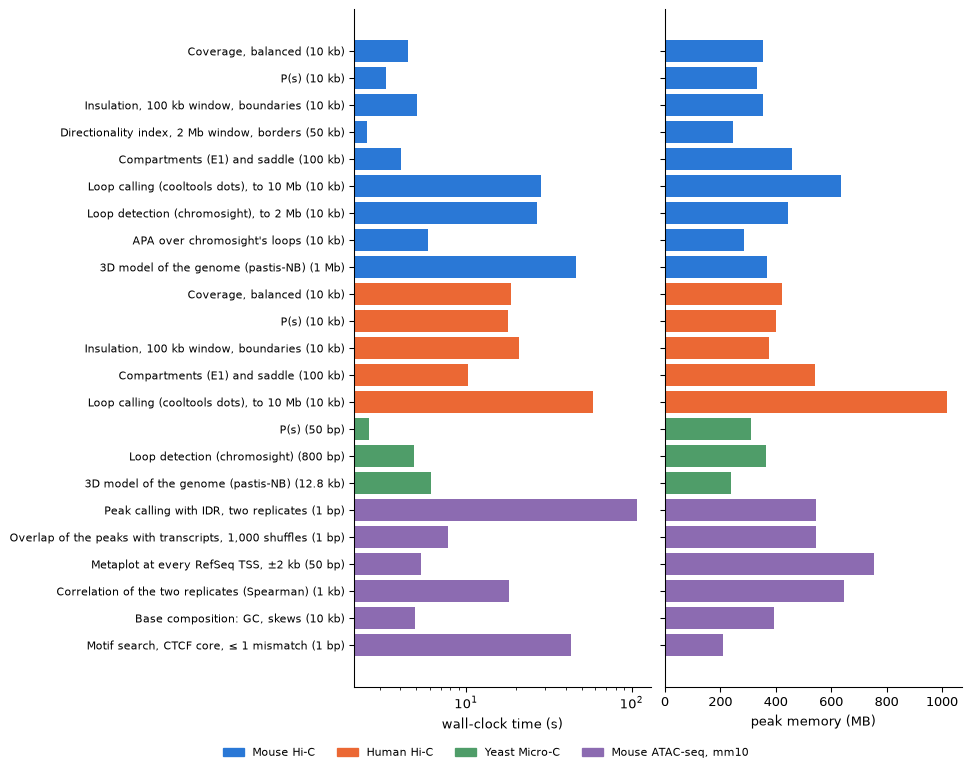

Figure 1: Wall-clock time (left, logarithmic) and peak memory (right) of each analysis, coloured by its data.

```python
colours = dict(zip(times['data'].unique(), ['#2a78d6', '#eb6834', '#4f9d69', '#8c6bb1']))
labels = [f'{a} ({r})' for a, r in zip(times['analysis'], times['resolution'])]
y = range(len(times))[::-1]
fig, (left, right) = plt.subplots(1, 2, figsize=(10, 0.3 * len(times) + 1), sharey=True, layout='constrained')
left.barh(y, times['wall_s'], color=times['data'].map(colours))
left.set(xscale='log', xlabel='wall-clock time (s)', yticks=list(y), yticklabels=labels)
right.barh(y, times['peak_mb'], color=times['data'].map(colours))
right.set(xlabel='peak memory (MB)')
fig.legend(handles=[Patch(color=colour, label=data) for data, colour in colours.items()], loc='outside lower center',
           ncols=len(colours), frameon=False, fontsize=8)
for ax in (left, right):
    ax.spines[['top', 'right']].set_visible(False)
    ax.tick_params(axis='y', labelsize=8)
plt.show()
```

## Every command

Run from `notebooks/work/laptop/`, each followed by `--out out/<name> --quiet`:

```bash
chromosomix coverage data/4DNFIOZ1TRUS.mcool::/resolutions/10000 --balance
chromosomix expected data/4DNFIOZ1TRUS.mcool::/resolutions/10000 --quantity expected --scope file
chromosomix insulation data/4DNFIOZ1TRUS.mcool::/resolutions/10000 --window 10
chromosomix di data/4DNFIOZ1TRUS.mcool::/resolutions/50000 --window 40
chromosomix compartments data/4DNFIOZ1TRUS.mcool::/resolutions/100000
chromosomix loops data/4DNFIOZ1TRUS.mcool::/resolutions/10000
chromosomix chromosight data/4DNFIOZ1TRUS.mcool::/resolutions/10000 --pattern loops
chromosomix apa data/4DNFIOZ1TRUS.mcool::/resolutions/10000 --pairs out/chromosight/4DNFIOZ1TRUS_10000.chromosight.chromosight-patterns.bedpe
chromosomix reconstruct3d data/4DNFIOZ1TRUS.mcool::/resolutions/1000000 --method nb --alpha 3
chromosomix coverage data/4DNFIJTOIGOI.mcool::/resolutions/10000 --balance
chromosomix expected data/4DNFIJTOIGOI.mcool::/resolutions/10000 --quantity expected --scope file
chromosomix insulation data/4DNFIJTOIGOI.mcool::/resolutions/10000 --window 10
chromosomix compartments data/4DNFIJTOIGOI.mcool::/resolutions/100000
chromosomix loops data/4DNFIJTOIGOI.mcool::/resolutions/10000
chromosomix expected data/GSE151553_A364_merged.mcool::/resolutions/50 --quantity expected --scope file
chromosomix chromosight data/GSE151553_A364_merged.mcool::/resolutions/800 --pattern loops
chromosomix reconstruct3d data/GSE151553_A364_merged.mcool::/resolutions/12800 --method nb --alpha 3
chromosomix peaks --signal data/4DNFIIY4QW2D.bw --replicate data/4DNFITBRHVZE.bw --width 150 --times 3 --minWidth 75 --truncate 100000 --idr 0.05
chromosomix overlap --sequence data/mm10.fa --features out/peaks/4DNFIIY4QW2D.peaks.peaks-data_4DNFIIY4QW2D_bw-data_4DNFITBRHVZE_bw.bed --features data/mm10.genes.gtf --a out/peaks/4DNFIIY4QW2D.peaks.peaks-data_4DNFIIY4QW2D_bw-data_4DNFITBRHVZE_bw.bed --b data/mm10.genes.gtf --shuffle --iterations 1000 --seed 1
chromosomix metaplot --tracks data/4DNFIIY4QW2D.bw --features data/mm10.genes.gtf --mode reference --at start --flank 2000 --step 50 --band none
chromosomix trackcorr --tracks data/4DNFIIY4QW2D.bw,data/4DNFITBRHVZE.bw --binsize 1000 --method spearman
chromosomix composition --sequence data/mm10.fa --resolution 10000
chromosomix motif --sequence data/mm10.fa --pattern CCGCGNGGNGGCAG --mismatches 1
```

*Rendered in 7 min 36 s, from 30 October 2026, 11:38 UTC to 11:45 UTC, by chromosomix 0.18.0 at `b1f1a7a3`.* This render, as JSON.